# Has the use of statistics produced a measurable result of run production in Major League Baseball, or are the latest numbers simply a normal progression of the game as time goes on?

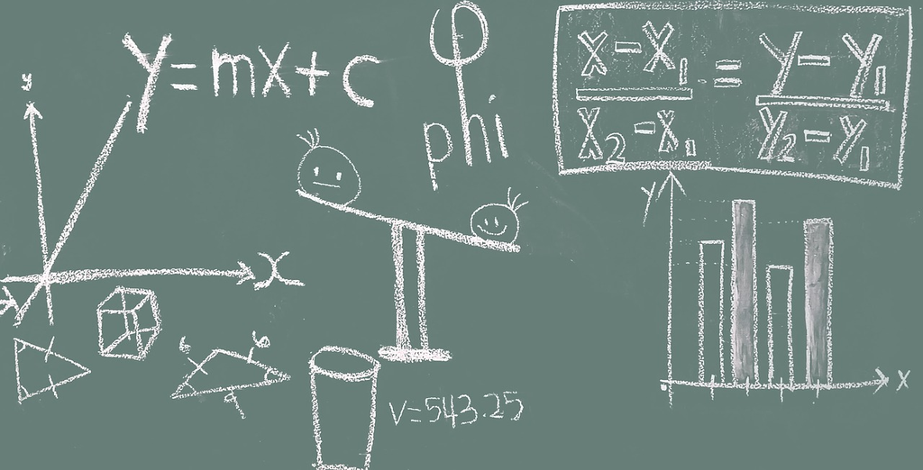

#### This is what we will dig through in the following slides. These slides will include means from three generations of the modern game: The lowered mound era, The steroid era, and The sabermetrics era.

#### In 1968, MLB made the last change they have made to the mound, the point from which the pitcher throws the ball. This change overturned a trend where pitching dominated batting, and the after effects of the lower mound were immdiately felt through increased offensive numbers, namely runs produced.

[figure not shown]

#### In 1991, Baseball adopted it's first anti-doping policy. It was never enforced and did not match watchdog lists, such as WADA, who oversees the Olympics. The period from 1991 until 2005 is widely known to baseball enthusiasts as the Steroid Era.

[figure not shown]

#### In 2003, the book Moneyball was released, ushering in the stats age called Sabermetrics. A high focus was placed on non-traditional stats as better indicators of run production. Whereas players were previosly measure on the statistics of batting average, home runs, and RBI, now th focus is on on base percentage, slugging percentage, and a new stat called on base plus slugging.

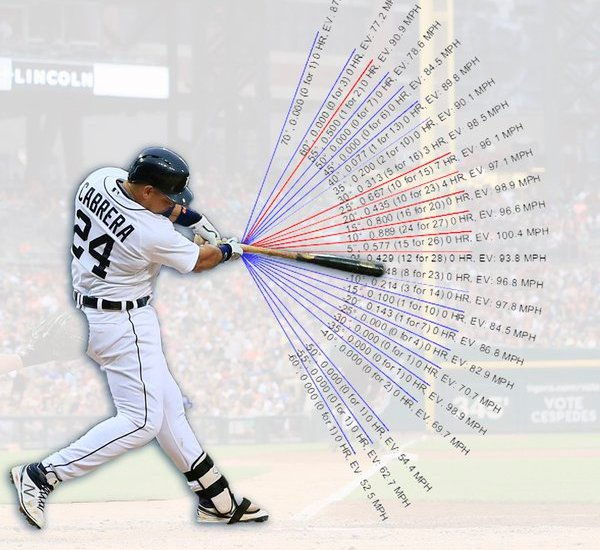

```python
lowerMound = batdata[(batdata['yearID'] >= 1968) & (batdata['yearID'] <= 1991) & (batdata['PA'] >= 502)]
lowerMound.describe()
```

|  | yearID | stint | G | AB | R | H | 2B | 3B | HR | RBI | SB | CS | BB | SO | IBB | HBP | SH | SF | GIDP | PA | OnBase | OBP | single | double | triple | homer | TB | SLUG | OPS | … |
| --- | --- | --- | --- | --- | --- | --- | --- | --- | --- | --- | --- | --- | --- | --- | --- | --- | --- | --- | --- | --- | --- | --- | --- | --- | --- | --- | --- | --- | --- | --- |
| count | 2760.000000 | 2760.000000 | 2760.000000 | 2760.000000 | 2760.000000 | 2760.000000 | 2760.000000 | 2760.000000 | 2760.000000 | 2760.000000 | 2760.000000 | 2760.000000 | 2760.000000 | 2760.000000 | 2760.000000 | 2760.000000 | 2760.000000 | 2760.000000 | 2760.000000 | 2760.000000 | 2760.000000 | 2760.000000 | 2760.000000 | 2760.000000 | 2760.000000 | 2760.000000 | 2760.000000 | 2760.000000 | 2760.000000 | … |
| mean | 1979.824638 | 1.005797 | 147.243478 | 541.988406 | 74.918841 | 149.353261 | 25.286957 | 4.080435 | 15.155435 | 69.844928 | 13.770652 | 6.243478 | 55.454710 | 76.294928 | 6.164855 | 3.250362 | 3.806884 | 4.854348 | 11.926812 | 605.547826 | 208.058333 | 0.342729 | 104.830435 | 50.573913 | 12.241304 | 60.621739 | 228.267391 | 0.420439 | 0.763169 | … |
| std | 6.871658 | 0.075931 | 9.902577 | 56.900693 | 17.827816 | 24.355502 | 7.344935 | 3.067924 | 10.183569 | 22.927922 | 15.805379 | 5.013949 | 22.230907 | 29.205276 | 5.031614 | 3.081942 | 4.493807 | 2.640297 | 5.069263 | 60.087732 | 33.081016 | 0.034787 | 21.413012 | 14.689870 | 9.203772 | 40.734277 | 46.231859 | 0.068504 | 0.093514 | … |
| min | 1968.000000 | 1.000000 | 111.000000 | 396.000000 | 25.000000 | 80.000000 | 6.000000 | 0.000000 | 0.000000 | 12.000000 | 0.000000 | 0.000000 | 11.000000 | 13.000000 | 0.000000 | 0.000000 | 0.000000 | 0.000000 | 0.000000 | 502.000000 | 112.000000 | 0.222000 | 39.000000 | 12.000000 | 0.000000 | 0.000000 | 115.000000 | 0.239000 | 0.461000 | … |
| 25% | 1974.000000 | 1.000000 | 141.000000 | 497.000000 | 62.000000 | 132.000000 | 20.000000 | 2.000000 | 7.000000 | 52.000000 | 3.000000 | 3.000000 | 39.000000 | 55.000000 | 2.000000 | 1.000000 | 1.000000 | 3.000000 | 8.000000 | 555.000000 | 184.000000 | 0.319000 | 90.000000 | 40.000000 | 6.000000 | 28.000000 | 194.000000 | 0.371000 | 0.698000 | … |
| 50% | 1979.000000 | 1.000000 | 149.000000 | 542.000000 | 74.000000 | 148.000000 | 25.000000 | 3.000000 | 14.000000 | 68.000000 | 8.000000 | 5.000000 | 52.500000 | 73.000000 | 5.000000 | 3.000000 | 2.000000 | 4.000000 | 11.000000 | 607.000000 | 205.000000 | 0.342000 | 103.000000 | 50.000000 | 9.000000 | 56.000000 | 225.000000 | 0.419000 | 0.762000 | … |
| 75% | 1986.000000 | 1.000000 | 155.000000 | 584.000000 | 86.250000 | 165.000000 | 30.000000 | 6.000000 | 22.000000 | 86.000000 | 19.000000 | 9.000000 | 69.000000 | 93.000000 | 9.000000 | 4.000000 | 6.000000 | 6.000000 | 15.000000 | 653.000000 | 230.000000 | 0.366000 | 118.000000 | 60.000000 | 18.000000 | 88.000000 | 259.000000 | 0.465000 | 0.824000 | … |
| max | 1991.000000 | 2.000000 | 163.000000 | 705.000000 | 146.000000 | 240.000000 | 54.000000 | 21.000000 | 52.000000 | 149.000000 | 130.000000 | 42.000000 | 148.000000 | 189.000000 | 45.000000 | 50.000000 | 40.000000 | 18.000000 | 36.000000 | 769.000000 | 342.000000 | 0.476000 | 187.000000 | 108.000000 | 63.000000 | 208.000000 | 406.000000 | 0.669000 | 1.118000 | … |

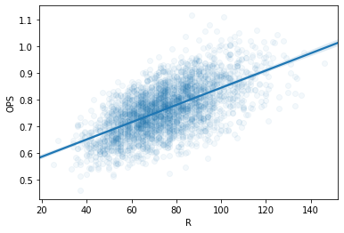

```python
sns.regplot(x='R', y='OPS', data=lowerMound, scatter_kws={'alpha':0.05})
plt.show()
```

```python
steroidEra = batdata[(batdata['yearID'] >= 1991) & (batdata['yearID'] <= 2005) & (batdata['PA'] >= 502)]
steroidEra.describe()
```

|  | yearID | stint | G | AB | R | H | 2B | 3B | HR | RBI | SB | CS | BB | SO | IBB | HBP | SH | SF | GIDP | PA | OnBase | OBP | single | double | triple | homer | TB | SLUG | OPS | … |
| --- | --- | --- | --- | --- | --- | --- | --- | --- | --- | --- | --- | --- | --- | --- | --- | --- | --- | --- | --- | --- | --- | --- | --- | --- | --- | --- | --- | --- | --- | --- |
| count | 1928.000000 | 1928.000000 | 1928.000000 | 1928.000000 | 1928.000000 | 1928.000000 | 1928.000000 | 1928.000000 | 1928.000000 | 1928.000000 | 1928.000000 | 1928.000000 | 1928.000000 | 1928.000000 | 1928.000000 | 1928.000000 | 1928.000000 | 1928.000000 | 1928.000000 | 1928.000000 | 1928.000000 | 1928.000000 | 1928.000000 | 1928.000000 | 1928.000000 | 1928.000000 | 1928.000000 | 1928.000000 | 1928.000000 | … |
| mean | 1998.567946 | 1.000519 | 146.213693 | 542.622925 | 84.008817 | 154.029564 | 30.147303 | 3.314834 | 19.884336 | 79.957988 | 12.589212 | 5.154046 | 59.251556 | 90.303423 | 5.509855 | 5.345954 | 2.607365 | 5.136929 | 12.257780 | 612.357365 | 218.627075 | 0.355899 | 100.683091 | 60.294606 | 9.944502 | 79.537344 | 250.459544 | 0.460829 | 0.816729 | … |
| std | 4.270018 | 0.022774 | 10.907260 | 57.459658 | 19.452133 | 24.104849 | 7.989295 | 2.804279 | 11.715606 | 25.892192 | 13.299017 | 4.310909 | 24.661623 | 30.025897 | 6.211704 | 4.453662 | 3.825581 | 2.704995 | 4.951392 | 63.374853 | 37.119737 | 0.038452 | 20.758869 | 15.978590 | 8.412838 | 46.862424 | 51.723843 | 0.078353 | 0.107967 | … |
| min | 1991.000000 | 1.000000 | 110.000000 | 373.000000 | 33.000000 | 80.000000 | 11.000000 | 0.000000 | 0.000000 | 17.000000 | 0.000000 | 0.000000 | 10.000000 | 14.000000 | 0.000000 | 0.000000 | 0.000000 | 0.000000 | 0.000000 | 502.000000 | 135.000000 | 0.259000 | 39.000000 | 22.000000 | 0.000000 | 0.000000 | 131.000000 | 0.291000 | 0.563000 | … |
| 25% | 1995.000000 | 1.000000 | 139.000000 | 495.000000 | 69.000000 | 136.000000 | 25.000000 | 1.000000 | 11.000000 | 60.000000 | 3.000000 | 2.000000 | 42.000000 | 69.000000 | 2.000000 | 2.000000 | 0.000000 | 3.000000 | 9.000000 | 558.000000 | 190.000000 | 0.329000 | 86.000000 | 50.000000 | 3.000000 | 44.000000 | 212.000000 | 0.403000 | 0.739000 | … |
| 50% | 1999.000000 | 1.000000 | 148.000000 | 542.000000 | 83.000000 | 153.000000 | 30.000000 | 3.000000 | 18.500000 | 78.000000 | 8.000000 | 4.000000 | 56.000000 | 88.000000 | 4.000000 | 4.000000 | 1.000000 | 5.000000 | 12.000000 | 615.000000 | 216.000000 | 0.353000 | 99.000000 | 60.000000 | 9.000000 | 74.000000 | 246.000000 | 0.454500 | 0.805000 | … |
| 75% | 2002.000000 | 1.000000 | 155.000000 | 586.000000 | 97.000000 | 170.000000 | 35.000000 | 5.000000 | 27.000000 | 100.000000 | 18.000000 | 7.000000 | 73.000000 | 109.250000 | 7.000000 | 7.000000 | 4.000000 | 7.000000 | 15.000000 | 666.000000 | 244.000000 | 0.379000 | 113.000000 | 70.000000 | 15.000000 | 108.000000 | 286.250000 | 0.509250 | 0.880000 | … |
| max | 2005.000000 | 2.000000 | 163.000000 | 704.000000 | 152.000000 | 262.000000 | 59.000000 | 21.000000 | 73.000000 | 165.000000 | 78.000000 | 28.000000 | 232.000000 | 195.000000 | 120.000000 | 34.000000 | 30.000000 | 17.000000 | 32.000000 | 773.000000 | 376.000000 | 0.609000 | 225.000000 | 118.000000 | 63.000000 | 292.000000 | 425.000000 | 0.863000 | 1.421000 | … |

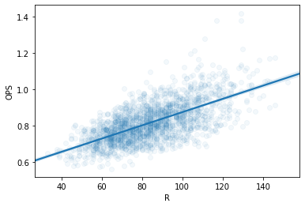

```python
sns.regplot(x='R', y='OPS', data=steroidEra, scatter_kws={'alpha':0.05})
plt.show()
```

```python
statsEra = batdata[(batdata['yearID'] >= 2003) & (batdata['PA'] >= 502)]
statsEra.describe()
```

|  | yearID | stint | G | AB | R | H | 2B | 3B | HR | RBI | SB | CS | BB | SO | IBB | HBP | SH | SF | GIDP | PA | OnBase | OBP | single | double | triple | homer | TB | SLUG | OPS | … |
| --- | --- | --- | --- | --- | --- | --- | --- | --- | --- | --- | --- | --- | --- | --- | --- | --- | --- | --- | --- | --- | --- | --- | --- | --- | --- | --- | --- | --- | --- | --- |
| count | 2221.000000 | 2221.0 | 2221.000000 | 2221.000000 | 2221.000000 | 2221.000000 | 2221.000000 | 2221.000000 | 2221.000000 | 2221.000000 | 2221.000000 | 2221.000000 | 2221.000000 | 2221.000000 | 2221.000000 | 2221.000000 | 2221.000000 | 2221.000000 | 2221.000000 | 2221.000000 | 2221.000000 | 2221.000000 | 2221.000000 | 2221.000000 | 2221.000000 | 2221.000000 | 2221.000000 | 2221.000000 | 2221.000000 | … |
| mean | 2010.335885 | 1.0 | 146.580819 | 545.470059 | 79.615939 | 151.263395 | 30.512832 | 3.111211 | 19.776227 | 76.105808 | 10.582170 | 3.754165 | 55.125619 | 103.457902 | 4.806394 | 5.633949 | 1.915353 | 4.597028 | 12.582620 | 610.826655 | 212.022963 | 0.346100 | 97.863125 | 61.025664 | 9.333633 | 79.104908 | 247.327330 | 0.452772 | 0.798872 | … |
| std | 4.633866 | 0.0 | 10.737464 | 57.062481 | 17.888410 | 24.272579 | 7.923306 | 2.868714 | 10.325203 | 22.390335 | 11.775303 | 3.492448 | 21.936394 | 33.297048 | 5.660387 | 4.281607 | 3.154725 | 2.398229 | 5.471716 | 62.499904 | 34.520433 | 0.034779 | 21.503848 | 15.846612 | 8.606141 | 41.300811 | 46.528297 | 0.067011 | 0.093637 | … |
| min | 2003.000000 | 1.0 | 109.000000 | 373.000000 | 30.000000 | 79.000000 | 9.000000 | 0.000000 | 0.000000 | 17.000000 | 0.000000 | 0.000000 | 9.000000 | 27.000000 | 0.000000 | 0.000000 | 0.000000 | 0.000000 | 0.000000 | 502.000000 | 127.000000 | 0.243000 | 32.000000 | 18.000000 | 0.000000 | 0.000000 | 127.000000 | 0.268000 | 0.539000 | … |
| 25% | 2006.000000 | 1.0 | 139.000000 | 501.000000 | 67.000000 | 133.000000 | 25.000000 | 1.000000 | 12.000000 | 59.000000 | 2.000000 | 1.000000 | 40.000000 | 79.000000 | 1.000000 | 3.000000 | 0.000000 | 3.000000 | 9.000000 | 559.000000 | 186.000000 | 0.323000 | 83.000000 | 50.000000 | 3.000000 | 48.000000 | 214.000000 | 0.405000 | 0.733000 | … |
| 50% | 2010.000000 | 1.0 | 148.000000 | 547.000000 | 78.000000 | 150.000000 | 30.000000 | 2.000000 | 19.000000 | 75.000000 | 6.000000 | 3.000000 | 52.000000 | 101.000000 | 3.000000 | 5.000000 | 0.000000 | 4.000000 | 12.000000 | 613.000000 | 211.000000 | 0.345000 | 97.000000 | 60.000000 | 6.000000 | 76.000000 | 243.000000 | 0.449000 | 0.791000 | … |
| 75% | 2014.000000 | 1.0 | 156.000000 | 589.000000 | 91.000000 | 168.000000 | 36.000000 | 4.000000 | 27.000000 | 91.000000 | 15.000000 | 5.000000 | 68.000000 | 124.000000 | 6.000000 | 8.000000 | 3.000000 | 6.000000 | 16.000000 | 661.000000 | 236.000000 | 0.367000 | 111.000000 | 72.000000 | 12.000000 | 108.000000 | 278.000000 | 0.496000 | 0.857000 | … |
| max | 2018.000000 | 1.0 | 163.000000 | 716.000000 | 143.000000 | 262.000000 | 56.000000 | 23.000000 | 59.000000 | 156.000000 | 78.000000 | 24.000000 | 232.000000 | 223.000000 | 120.000000 | 30.000000 | 24.000000 | 16.000000 | 32.000000 | 778.000000 | 376.000000 | 0.609000 | 225.000000 | 112.000000 | 69.000000 | 236.000000 | 394.000000 | 0.812000 | 1.421000 | … |

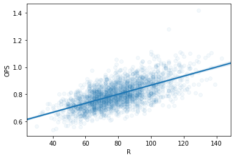

```python
sns.regplot(x='R', y='OPS', data=statsEra, scatter_kws={'alpha':0.05})
plt.show()
```

*Notice how the cluster flattens, elongates in the steroid and stats eras. It is obvious something changed in these eras that tighetned the spectrum of the mean production.*

*These next data sets are created to test the progression of the game. As part of my hypothesis, increased player skill levels due to amount of time playing the game and the progression of the game itself (the longer it is played, the better everyone gets, which ultimately cancels one another out) results in better play on it's own as players reach theoretical max levels of production. If stats driven development is truly at play, this is where it ought to show up most visibly: data sets taken from the last five years of each data set.*

*Additionally, the loweredMound era has a significant change that ocurred: free agency. This alloweed players to change teams, bid out thir services, and make enough money to begin focusing on baseball full-time rather than having normal jobs in the offseason. This happened in the 70s and changed the face of the game.*

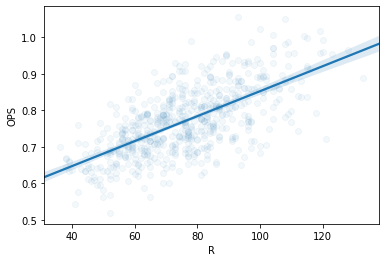

```python
sns.regplot(x='R', y='OPS', data=lmLastFive, scatter_kws={'alpha':0.05})
plt.show()
```

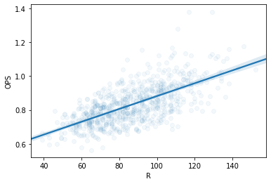

```python
sns.regplot(x='R', y='OPS', data=sdLastFive, scatter_kws={'alpha':0.05})
plt.show()
```

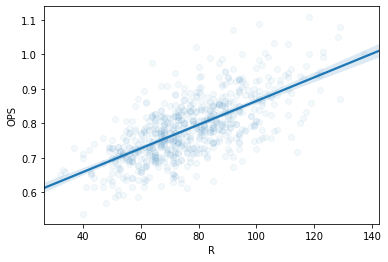

```python
sns.regplot(x='R', y='OPS', data=stLastFive, scatter_kws={'alpha':0.05})
plt.show()
```

*Through these we see that the steroid era is still outperforming everyone.*

*The lmLastFive and stLastFive, however, look very similar. Let's drop the steroid era as an outlier and look more closely at the other two datasets on a histogram and see how they overlay.*

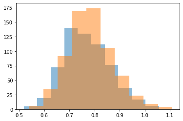

```python
plt.hist(lmLastFive['OPS'], alpha=.5)
plt.hist(stLastFive['OPS'], alpha=.5)
plt.show()
```

*And now the R production.*

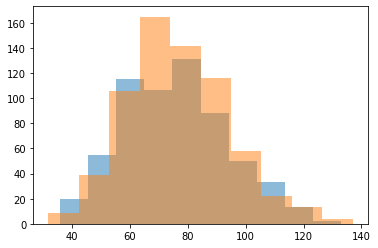

```python
plt.hist(lmLastFive['R'], alpha=.5)
plt.hist(stLastFive['R'], alpha=.5)
plt.show()
```

*Again, they look very similar.*

*Let's look at some sample means for the two eras to make sure our data is normally distributed.*

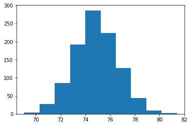

```python
lmMeans = [lowerMound['R'].sample(n = 100).mean() for _ in range(1000)]
plt.hist(lmMeans);
```

[figure not shown]

```python
stMeans = [statsEra['R'].sample(n = 100).mean() for _ in range(1000)]
plt.hist(stMeans);
```

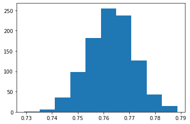

```python
lmMeans = [lowerMound['OPS'].sample(n = 100).mean() for _ in range(1000)]
plt.hist(lmMeans);
```

[figure not shown]

```python
stMeans = [statsEra['OPS'].sample(n = 100).mean() for _ in range(1000)]
plt.hist(stMeans);
```

*Since the means are all distributed normally, let's run a series of Ttests and see where there is significant difference and where there is not.*

*Ttest of eras lowerMound and stats, given the presumption of a lack of PED usage.*

```python
print(stats.ttest_ind(lowerMound['OPS'], statsEra['OPS'])) #null = reject pvalue=9.264435572999819e-08
print(stats.ttest_ind(lowerMound['R'], statsEra['R'])) #null = reject pvalue=0.028278847088743862
print(stats.ttest_ind(lowerMound['OBP'], statsEra['OBP'])) #null = rejct pvalue=0.005822886802050661
print(stats.ttest_ind(lowerMound['SLUG'], statsEra['SLUG'])) #null = reject pvalue=3.059099661607167e-18
print(stats.ttest_ind(lowerMound['BA'], statsEra['BA'])) #null = reject pvalue=0.00029315404042579276
print(stats.ttest_ind(lowerMound['PA'], statsEra['PA'])) #null = accept
print(stats.ttest_ind(lowerMound['AB'], statsEra['AB'])) #null = accept
```

```
Ttest_indResult(statistic=-5.352096706516884, pvalue=9.264435572999819e-08)
Ttest_indResult(statistic=-2.1943250154243454, pvalue=0.028278847088743862)
Ttest_indResult(statistic=2.759321148067626, pvalue=0.005822886802050661)
Ttest_indResult(statistic=-8.758230406552341, pvalue=3.059099661607167e-18)
Ttest_indResult(statistic=3.6250020193435937, pvalue=0.00029315404042579276)
Ttest_indResult(statistic=-0.4307034370593669, pvalue=0.6667110660596509)
Ttest_indResult(statistic=-0.6934771259789159, pvalue=0.48805710481748343)
```

*Our AB and PA show no signs of significance, but everything else suggests there is significance between the two eras. Now we will look at the last five years of each era and see if anything changes.*

```python
print(stats.ttest_ind(lmLastFive['OPS'], stLastFive['OPS'])) #null = reject pvalue=0.004930227014237343
print(stats.ttest_ind(lmLastFive['R'], stLastFive['R'])) #null = accept
print(stats.ttest_ind(lmLastFive['OBP'], stLastFive['OBP'])) #null = reject pvalue=0.012989154868119981
print(stats.ttest_ind(lmLastFive['SLUG'], stLastFive['SLUG'])) #null = reject pvalue=1.6788897883125095e-07
print(stats.ttest_ind(lmLastFive['BA'], stLastFive['BA'])) #null = reject pvalue=0.007870697821893905
print(stats.ttest_ind(lmLastFive['PA'], stLastFive['PA'])) #null = accept
print(stats.ttest_ind(lmLastFive['AB'], stLastFive['AB'])) #null = accept
```

```
Ttest_indResult(statistic=-2.8164325144059137, pvalue=0.004930227014237343)
Ttest_indResult(statistic=-0.6558684942228415, pvalue=0.5120260610536571)
Ttest_indResult(statistic=2.4875337925894367, pvalue=0.012989154868119981)
Ttest_indResult(statistic=-5.260770227744551, pvalue=1.6788897883125095e-07)
Ttest_indResult(statistic=2.661738424456634, pvalue=0.007870697821893905)
Ttest_indResult(statistic=-0.6205259636066971, pvalue=0.5350215153592877)
Ttest_indResult(statistic=-1.2384561204859503, pvalue=0.21577300021623674)
```

*And that is very interesting. Everything fell along the same lines, though with reduced distance, until R, which flipped from rejecting the null to accepting it. When comparing the last five years of players in lowerMound, 1987-1991, to the last five years of players in the stats generation, 2014-18, R did not show significance.*

*Conclusion from this test:*